# Combining automated monitering and bayesian occupancy models for detecting rare plant-animal interactions

## Occupancy model formulation

For each hummingbird (i), plant (j) and month (k):

$Y_{i,j,k} \sim Bern(sightp_{i,j,k})$ $sightp_{i,j,k} = present_{i,j} * detect$ $present_{i,j} \sim Bern(occ)$

```
##  [1] setwd("C:/Users/Ben/Documents/Occupy/Bayesian")
##  [2]
##  [3] sink("Simulation.jags")
##  [4]
##  [5] cat("
##  [6]     model {
##  [7]       for (i in 1:Birds){
##  [8]         for (j in 1:Plants){
##  [9]         # True state model for the only partially observed true state
## [10]           present[i,j] ~ dbern(occ)
## [11]           for (k in 1:Months) {
## [12]             # Observation model for the actual observations
## [13]             sightp[i,j,k] <- present[i,j] * detect
## [14]             Y[i,j,k] ~ dbern(sightp[i,j,k])
## [15]           }
## [16]         }
## [17]       }
## [18]     occ ~ dunif(0,1)
## [19]     detect ~ dunif(0,1)
## [20]     }
## [21]     ",fill=TRUE)
## [22]
## [23] sink()
```

```
##    Graph Size: 1827
##
```

### Assess Convergence

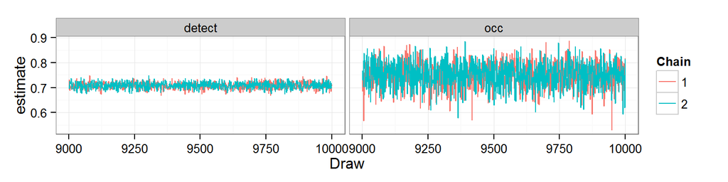

### Posteriors

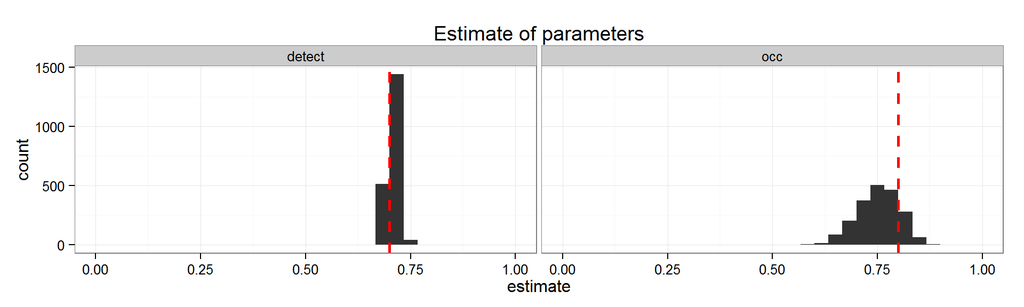

## Simulation 1: Constant occupancy and detection for each hummingbird species

Consider a matrix of interactions, where we assume interactions among plants and hummingbirds are independent.

### Parameters

- 7 hummingbirds
- 10 plants
- Known occupancy $\psi = U(.5,1)$
  - At very low occupancies, the interaction is too rare to estimate.
- Imperfect detection $p = U(0,1)$
- 24 Months replicates

Each species gets their own occupancy and imperfect detection which is drawn from uniform distribution. The goal is **recover these parameters**.

### True Interaction Matrix

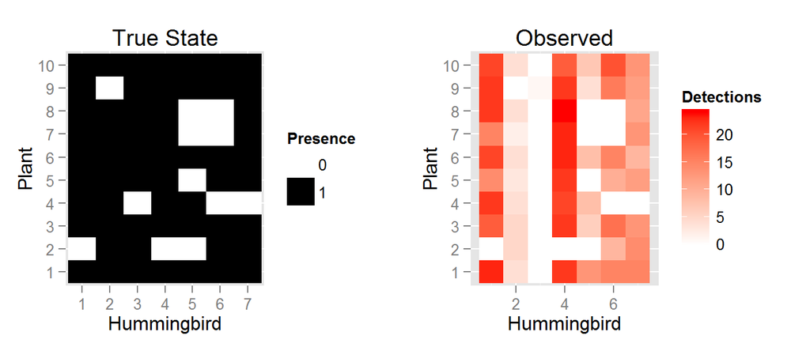

Data is stored in a multidimensional array Hummingbird 1 on Plant 1 - True State is Present

```
## [1] 1
```

Observed state from the simulated transect data

**Format is [Hummingbird,Plants,Month]**

```
##  [1] 1 1 1 1 1 1 1 1 1 1 1 1 1 1 1 1 1 1 1 0 1 1 1 1
```

## Occupancy model formulation

For each hummingbird (i), plant (j) and month (k):

$Y_{i,j,k} \sim Bern(sightp_{i,j,k})$ $sightp_{i,j,k} = present_{i,j} * detect_i$ $present_{i,j} \sim Bern(occ_i)$

```
##  [1] setwd("C:/Users/Ben/Documents/Occupy/Bayesian")
##  [2]
##  [3] sink("Simulation1.jags")
##  [4]
##  [5] cat("
##  [6]     model {
##  [7]       for (i in 1:Birds){
##  [8]         for (j in 1:Plants){
##  [9]         # True state model for the only partially observed true state
## [10]           present[i,j] ~ dbern(occ[i])
## [11]           for (k in 1:Months) {
## [12]             # Observation model for the actual observations
## [13]             sightp[i,j,k] <- present[i,j] * detect[i]
## [14]             Y[i,j,k] ~ dbern(sightp[i,j,k])
## [15]           }
## [16]         }
## [17]       }
## [18]
## [19]     for (i in 1:Birds){
## [20]     occ[i] ~ dnorm(0.5,1)
## [21]     detect[i] ~ dnorm(0.5,1)
## [22]     }
## [23]   }
## [24]     ",fill=TRUE)
## [25]
## [26] sink()
```

```
##    Graph Size: 1839
##
```

### Assess Convergence

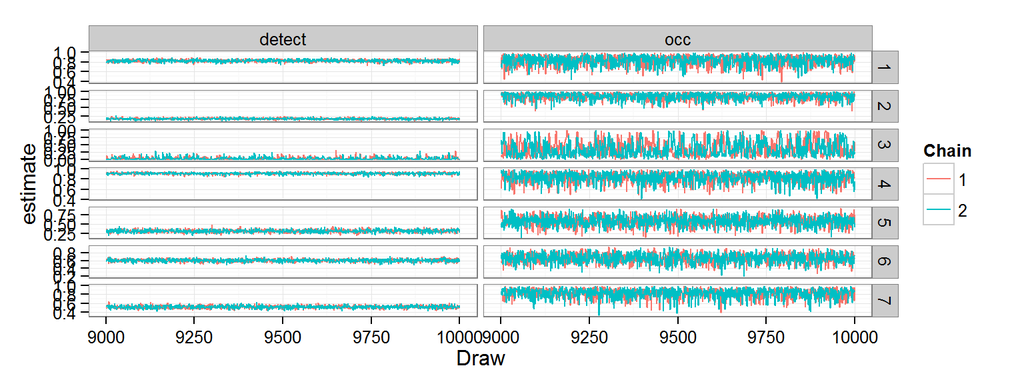

### Posteriors

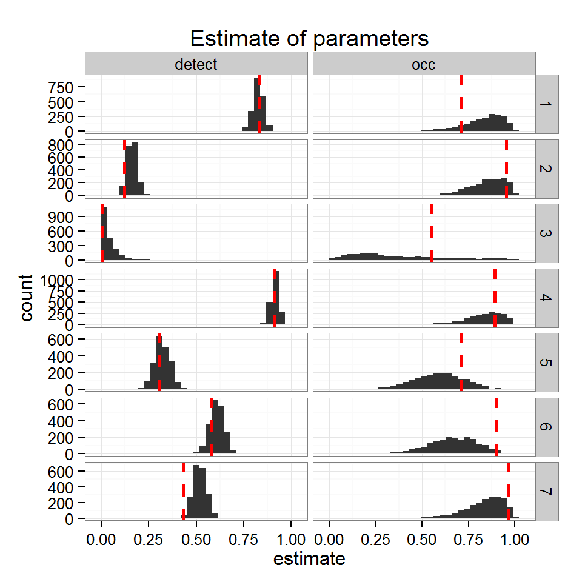

**True values are given in the red dashed lines.** Species are the rows.

## Conclusion

We were able to recover the true data for detection, but less accurate for occupancy (the right hand column).

**Question 1: Why is occupancy harder to predict? Do we need more data? The chains look pretty converged. There are two types of additional data, more sites (flowers) and more visits (replicates), which type of data will help us estimate more accurately?**

## Simulation 2: Constant detection but variable occupancy for each hummingbird species for each plant

Here we assume that the probability of detection is related to abundance and the abundance of species is constant within the sampling window. Therefore each hummingbird species gets a detection probability, but each plant-hummingbird gets a occupancy.

### Parameters

- 7 hummingbird species
- 5 plants
- Variable occupancy for each plant $\psi_{i,j} = U(0,1)$
- Imperfect detection $p = U(0,1)$ for each hummingbird species
- 24 Months replicates

### True Interaction Matrix

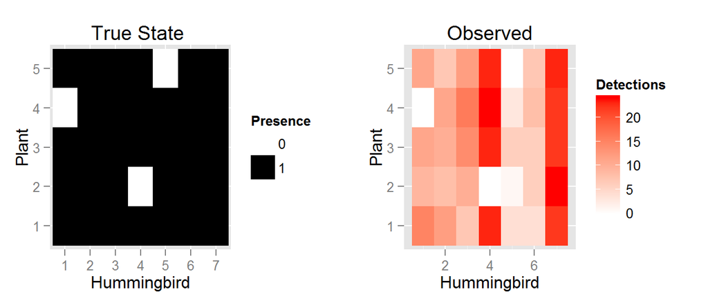

## Occupancy Model Formulation

$Y_{i,j,k} \sim Bern(sightp_{i,j,k})$ $sightp_{i,j,k} = present_{i,j} * detect_i$ $present_{i,j} \sim Bern(occ_{i,j})$

```
##  [1] setwd("C:/Users/Ben/Documents/Occupy/Bayesian")
##  [2]
##  [3] sink("Simulation2.jags")
##  [4]
##  [5] cat("
##  [6]     model {
##  [7]     for (i in 1:Birds){
##  [8]       for (j in 1:Plants){
##  [9]         # True state model for the only partially observed true state
## [10]         present[i,j] ~ dbern(occ[i,j])
## [11]         for (k in 1:Months) {
## [12]           # Observation model for the actual observations
## [13]           sightp[i,j,k] <- present[i,j] * detect[i]
## [14]           Y[i,j,k] ~ dbern(sightp[i,j,k])
## [15]           }
## [16]         }
## [17]       }
## [18]     for (i in 1:Birds){
## [19]       detect[i] ~ dnorm(.5,1) # Detection for each bird species
## [20]       for (j in 1:Plants){
## [21]         occ[i,j] ~ dnorm(.5,1) # Occupancy for each Bird-Plant combination
## [22]         }
## [23]       }
## [24]     }
## [25]     ",fill=TRUE)
## [26]
## [27] sink()
```

```
##    Graph Size: 957
##
```

### Assess Convergence

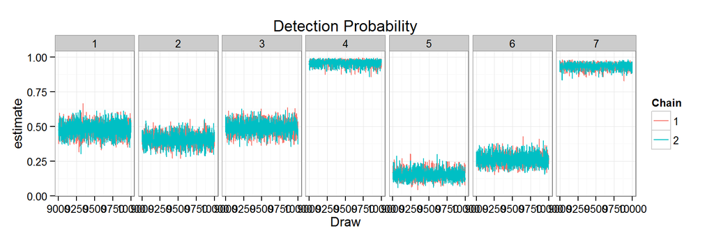

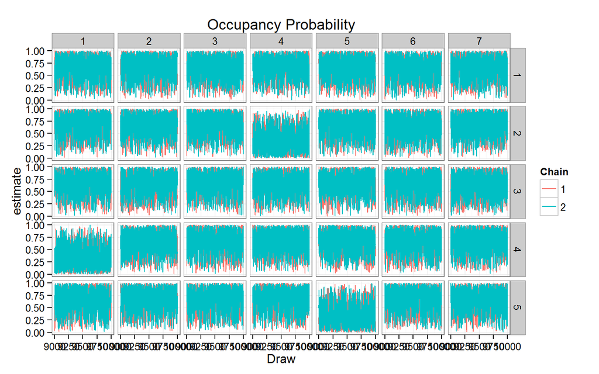

### Posteriors

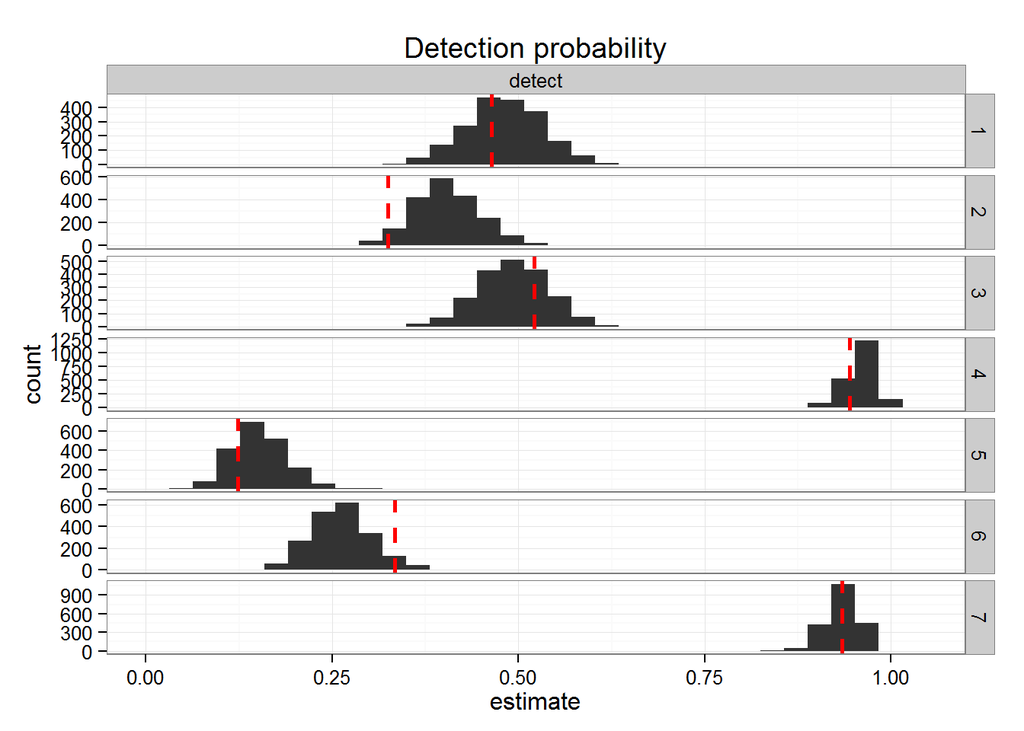

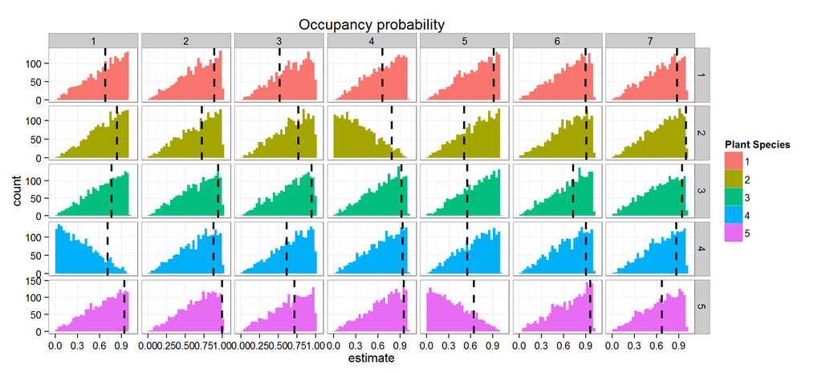

**True values are given in the dashed lines.**

## Simulation 3: Constant detection and varying occupancy drawn from a hierarcichal distribution.

Here we assume that the probability of detection is related to abundance and the abundance of species is constant within the sampling window. Therefore each hummingbird species gets a detection probability, but each plant-hummingbird gets a occupancy.

### Parameters

- 7 hummingbird species
- Ten plants
- Mean occupancy ($\gamma$) for each hummingbird is drawn from U(0.5,1)
  - For each plant the occupancy is N($\gamma$,0.1)
- Imperfect detection $p = U(0,1)$ for each hummingbird species
- 24 months replicates

### True Interaction Matrix

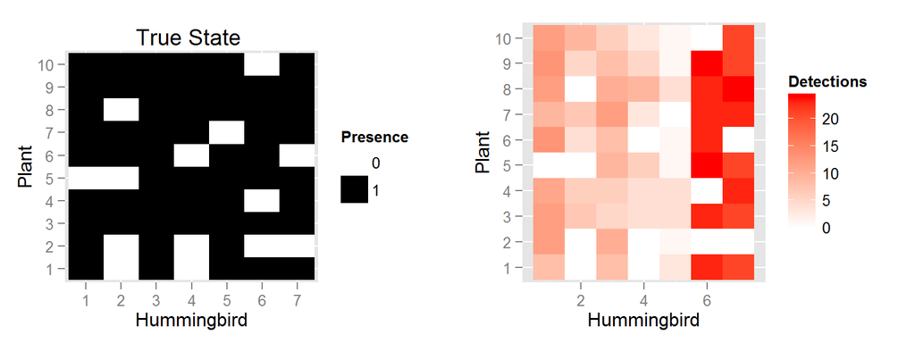

## Occupancy Model Formulation

$Y_{i,j,k} \sim Bern(sightp_{i,j,k})$ $sightp_{i,j,k} = present_{i,j} * detect_i$ $present_{i,j} \sim Bern(occ_{i,j})$

Where $occ_{i,j} ~ N(\gamma,\sigma)$

```
##  [1] setwd("C:/Users/Ben/Documents/Occupy/Bayesian")
##  [2]
##  [3] sink("Simulation3.jags")
##  [4]
##  [5] cat("
##  [6]     model {
##  [7]
##  [8]     for (i in 1:Birds){
##  [9]       for (j in 1:Plants){
## [10]         # True state model for the only partially observed true state
## [11]         present[i,j] ~ dbern(occ[i,j])
## [12]         for (k in 1:Months) {
## [13]           # Observation model for the actual observations
## [14]           sightp[i,j,k] <- present[i,j] * detect[i]
## [15]           Y[i,j,k] ~ dbern(sightp[i,j,k])
```

[output cut: 19 more lines]

```
##    Graph Size: 1932
##
```

### Assess Convergence

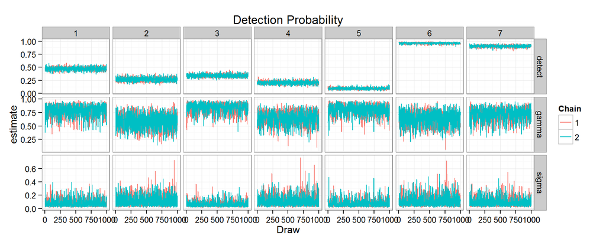

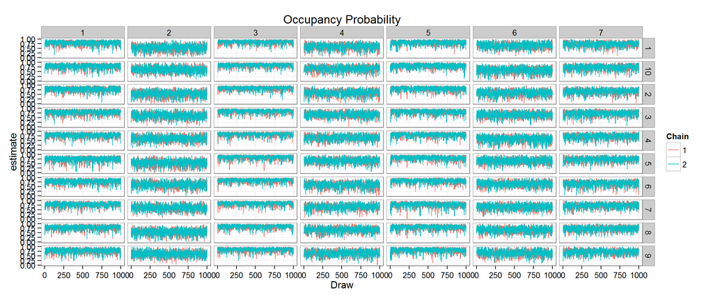

### Posteriors

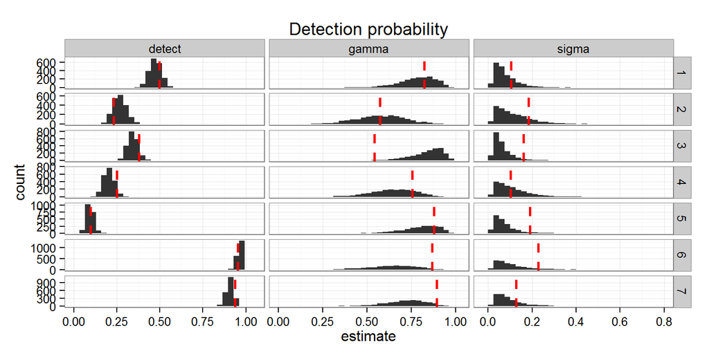

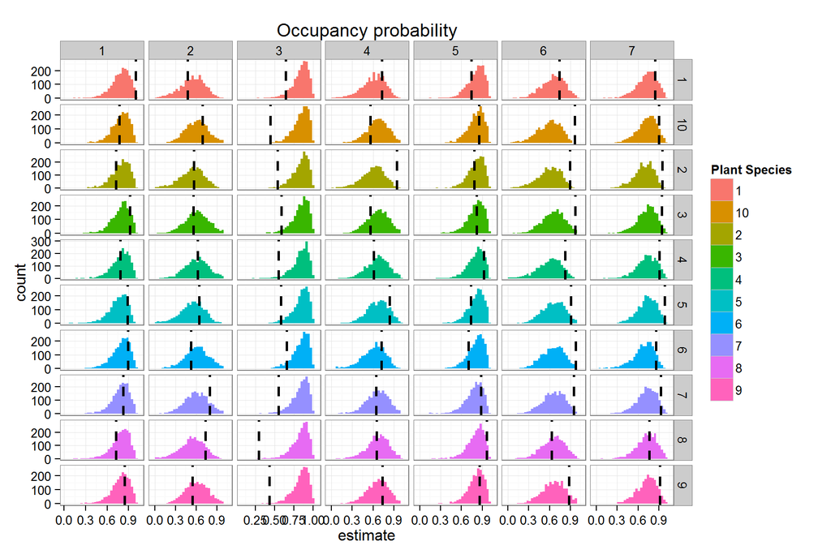

**True values are given in the dashed lines.**

# Simulation 4: Hierarchical occupancy with uneven sampling.

Here we assume that the probability of detection is related to abundance and the abundance of species is constant within the sampling window. Therefore each hummingbird species gets a detection probability, but each plant-hummingbird gets a occupancy. However, each plant is only in flower during a certain number of transects. Add a phenology parameter, expressed as a proportion of surveys where the plant is available.

### Parameters

- 7 hummingbird species
- Ten plants
- Mean occupancy ($\gamma$) for each hummingbird is drawn from U(0.5,1)
  - For each plant the occupancy is N($\gamma$,0.2)
- Imperfect detection $p = U(0,1)$ for each hummingbird species
- 24 months replicates
- Phenology = .75 (plants are in flower 3/4 of surveys)

### True Interaction Matrix

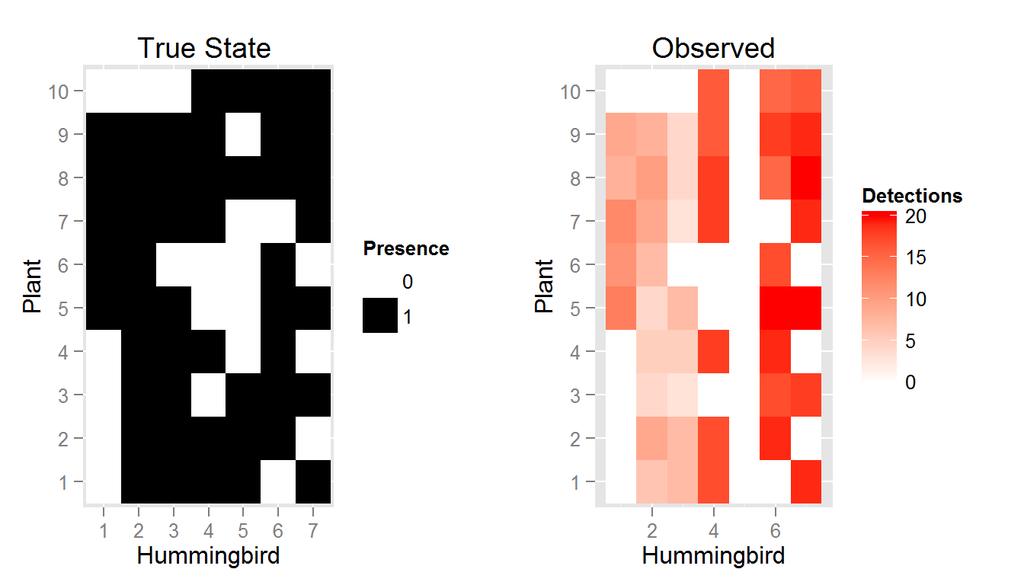

## Occupancy Model Formulation

$Y_{i,j,k} \sim Bern(sightp_{i,j,k})$ $sightp_{i,j,k} = present_{i,j} * detect_i$ $present_{i,j} \sim Bern(occ_{i,j})$

Where:

$occ_{i,j} ~ N(\gamma,\sigma)$

```
##  [1] setwd("C:/Users/Ben/Documents/Occupy/Bayesian")
##  [2] #Data is ragged and indexed to remove NA's
##  [3]
##  [4] sink("Simulation4.jags")
##  [5]
##  [6] cat("
##  [7]     model {
##  [8]
##  [9]     for (i in 1:Birds){
## [10]
## [11]       for (j in 1:Plants){
## [12]         # True state model for the only partially observed true state
## [13]         present[i,j] ~ dbern(occ[i,j])
## [14]
## [15]         for (k in 1:Months) {
```

[output cut: 21 more lines]

```
##    Graph Size: 1932
##
```

### Assess Convergence

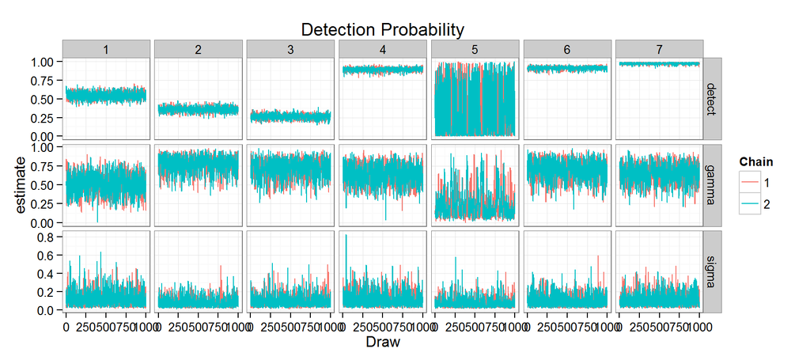

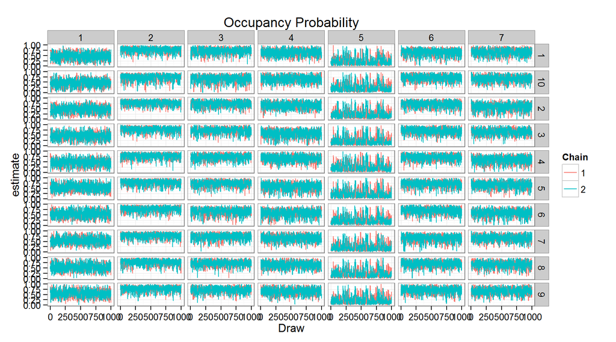

### Posteriors

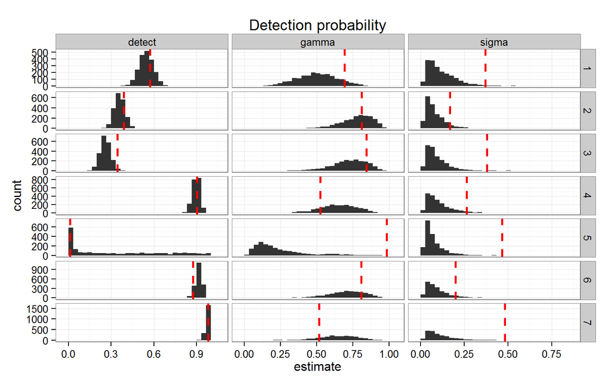

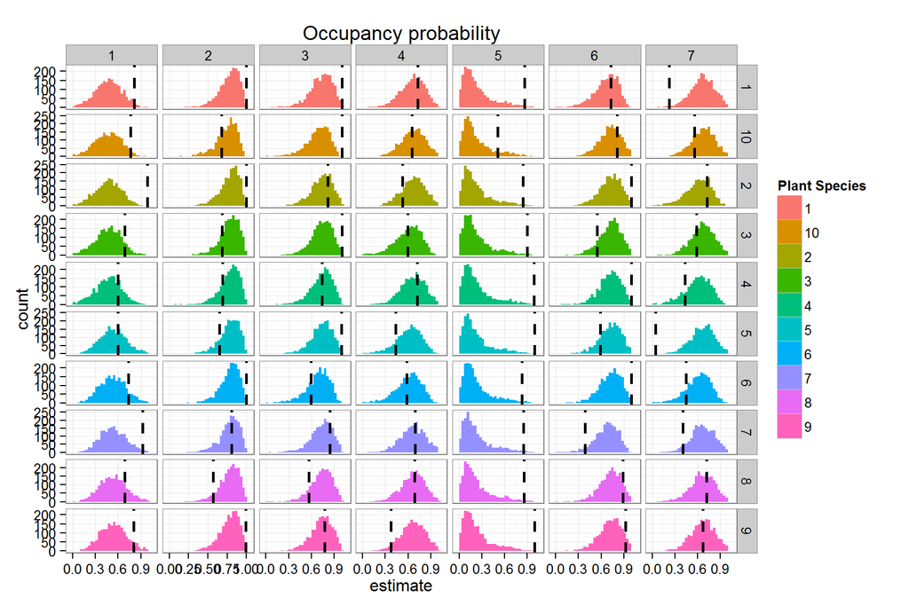

**True values are given in the dashed lines.**

# What have we learned so far?

- Detection is easy to estimate.
- Occupancy is harder to estimate
- Adding a hierarchical term yields much better estimates of known values of occupancy
- Given data sizes we are likely to see in the field, it is not possible to model every interaction seperately and get believable estimates.
- Its unclear whether the lack of solid estimates in Simulation 2 especially is due to lack of convergence, or just not enough data.
- I’m concerned about how high occupancy needs to be to estimatable.

# Simulation 5: Constant detection for each hummingbird speices, occupancy is function of species hierarcichal model and corolla similarity. Uneven sampling among species.

### Parameters

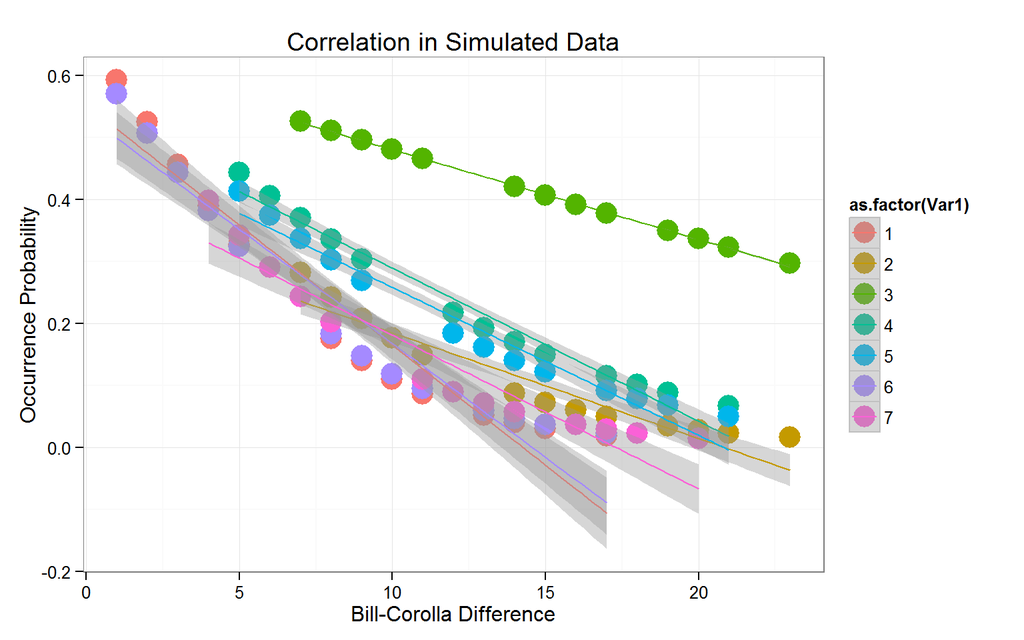

### True Interaction Matrix

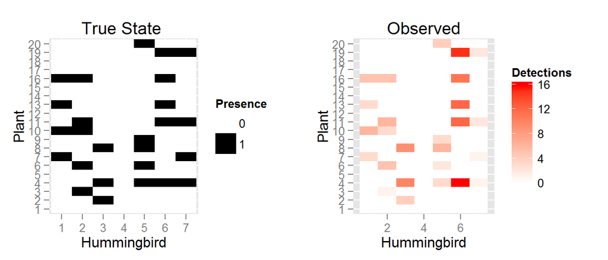

## Occupancy Model Formulation

$Y_{i,j,k} \sim Bern(sightp_{i,j,k})$ $sightp_{i,j,k} = present_{i,j} * detect_i$ $present_{i,j} \sim Bern(occ_{i,j})$ $occ_{i,j}<-\alpha + \beta * (Bill_i - Corolla_i)$

```
##  [1] setwd("C:/Users/Ben/Documents/Occupy/Bayesian")
##  [2]
##  [3] sink("Simulation5.jags")
##  [4]
##  [5] cat("
##  [6]     model {
##  [7]     for (i in 1:Birds){
##  [8]       for (j in 1:Plants){
##  [9]
## [10]     # True state model for the only partially observed true state
## [11]     logit(occ[i,j])<-alpha[i] + beta[i] * traitmatch[i,j]
## [12]     present[i,j] ~ dbern(occ[i,j])
## [13]
## [14]     for (k in 1:Months) {
## [15]       # Observation model for the actual observations
```

[output cut: 26 more lines]

```
##    Graph Size: 4089
##
```

### Assess Convergence

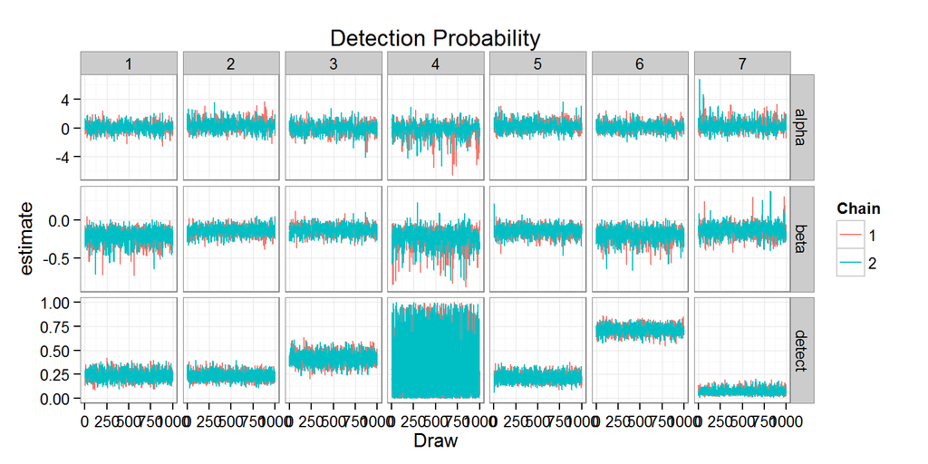

### Posteriors

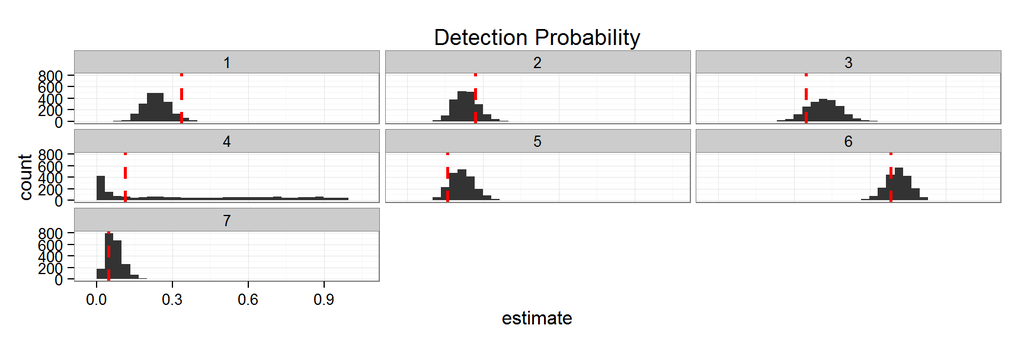

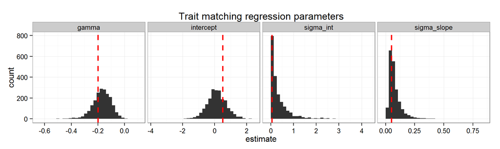

**True values are given in the dashed lines.**

### Predicted Relationship

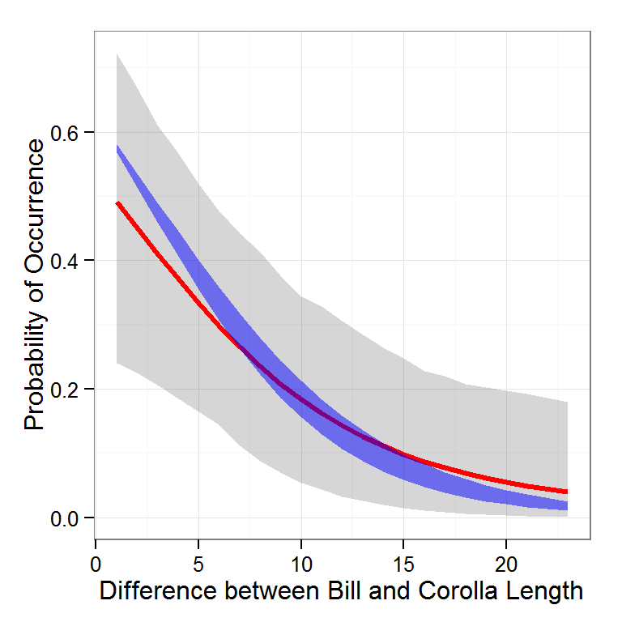

# Simulations to do

- Hierarchical model where species-plant level covariates are estimated as a function of the species distrubtion * additional predictors such as traits and abundance of plants
- Varying time models?
- Get predicted networks based on output of models, need to build a function. Compare predicted and observed.

# Next steps

- Define closed population period
- Create model comparison for env correlates
  - Elevation
  - Time
  - Behavioral Strategy (as defined by morphology or field observations)
- Create predictions of interactions
- Compare corrected and uncorrected interaction networks, models, and inferences.